# Week_9

Nicholas Koppert

2025-10-01

# Week 9: Working with sequence data in R

Introduction: We will be doing… -Download sequence files, unzip them and read them into R. -Perform simple manipulations and analyses with sequence data. -Use provided functions to calculate amino acid and nucleotide frequency. -Use provided functions to calculate codon usage bias. -Use provided tools to calculate protein sequence k-mer frequency.

```r
suppressPackageStartupMessages({
library ("seqinr") # is a package designed to process and analyse sequence data.
library ("R.utils") # general utilities like zip and unzip
})
```

## Loading E.coli sequence data

We will be downloading E. coli genomic sequence data from Ensembl . Ensembl is one of the biggest databases of genomic data. There are many E. coli strains available in Ensembl, but we will focus today on “Escherichia coli str. K-12 substr.MG1655 str. K12 (GCA_000005845)”.

HAD to # the gunzip command. Why?

```r
library("R.utils")
URL="http://ftp.ensemblgenomes.org/pub/bacteria/release-53/fasta/bacteria_0_collection/escherichia_coli_str_k_12_substr_mg1655_gca_000005845/cds/Escherichia_coli_str_k_12_substr_mg1655_gca_000005845.ASM584v2.cds.all.fa.gz"
download.file(URL,destfile="ecoli_cds.fa.gz")
# gunzip("ecoli_cds.fa.gz")
list.files()
```

```
## [1] "DESeq2_Analysis"   "ecoli_cds.fa"      "ecoli_cds.fa.gz"
## [4] "LICENSE"           "README.md"         "SLE777_test.Rproj"
## [7] "test.rmd"          "Week9.html"        "Week9.Rmd"
```

Load the seqinr library: This library provides tools for biological sequence retrieval and analysis.

```r
library("seqinr")
```

## Reading the fasta file

The code below reads the uncompressed FASTA file ecoli_cds.fa containing Escherichia coli coding sequences into R using the read.fasta function from the seqinr package. The str(head(cds)) function then provides a structured summary of the first few sequences, giving an overview of the data’s structure and content.

In this output each sequence is identified by a code (e.g., AAC73112) and stored as a character vector of nucleotides (A, T, G, C). The name attribute gives the sequence ID, and the Annot attribute provides additional information, such as the sequence’s location on the chromosome and the associated gene. The sequences vary in length, reflecting different gene sizes.

```r
cds <- seqinr::read.fasta("ecoli_cds.fa")
str(head(cds))
```

```
## List of 6
##  $ AAC73112: 'SeqFastadna' chr [1:66] "a" "t" "g" "a" ...
##   ..- attr(*, "name")= chr "AAC73112"
##   ..- attr(*, "Annot")= chr ">AAC73112 cds chromosome:ASM584v2:Chromosome:190:255:1 gene:b0001 gene_biotype:protein_coding transcript_biotyp"| __truncated__
##  $ AAC73113: 'SeqFastadna' chr [1:2463] "a" "t" "g" "c" ...
##   ..- attr(*, "name")= chr "AAC73113"
##   ..- attr(*, "Annot")= chr ">AAC73113 cds chromosome:ASM584v2:Chromosome:337:2799:1 gene:b0002 gene_biotype:protein_coding transcript_bioty"| __truncated__
##  $ AAC73114: 'SeqFastadna' chr [1:933] "a" "t" "g" "g" ...
##   ..- attr(*, "name")= chr "AAC73114"
##   ..- attr(*, "Annot")= chr ">AAC73114 cds chromosome:ASM584v2:Chromosome:2801:3733:1 gene:b0003 gene_biotype:protein_coding transcript_biot"| __truncated__
##  $ AAC73115: 'SeqFastadna' chr [1:1287] "a" "t" "g" "a" ...
##   ..- attr(*, "name")= chr "AAC73115"
##   ..- attr(*, "Annot")= chr ">AAC73115 cds chromosome:ASM584v2:Chromosome:3734:5020:1 gene:b0004 gene_biotype:protein_coding transcript_biot"| __truncated__
##  $ AAC73116: 'SeqFastadna' chr [1:297] "g" "t" "g" "a" ...
##   ..- attr(*, "name")= chr "AAC73116"
##   ..- attr(*, "Annot")= chr ">AAC73116 cds chromosome:ASM584v2:Chromosome:5234:5530:1 gene:b0005 gene_biotype:protein_coding transcript_biot"| __truncated__
##  $ AAC73117: 'SeqFastadna' chr [1:777] "a" "t" "g" "c" ...
##   ..- attr(*, "name")= chr "AAC73117"
##   ..- attr(*, "Annot")= chr ">AAC73117 cds chromosome:ASM584v2:Chromosome:5683:6459:-1 gene:b0006 gene_biotype:protein_coding transcript_bio"| __truncated__
```

## Basic sequence analysis

Now we can figure out the number of coding sequences.

```r
length(cds)
```

```
## [1] 4239
```

The summary(cds) function generates a detailed summary of the sequences, including their lengths, classes, and modes, while head limits the output to the initial entries.

```r
head(summary(cds))
```

```
##          Length Class       Mode
## AAC73112   66   SeqFastadna character
## AAC73113 2463   SeqFastadna character
## AAC73114  933   SeqFastadna character
## AAC73115 1287   SeqFastadna character
## AAC73116  297   SeqFastadna character
## AAC73117  777   SeqFastadna character
```

Now let’s determine the total length of our sequence. The code below extracts the lengths of genes from the cds object by converting the first column of the summary to numeric values. It then calculates the total length of all genes by summing these values. TOTAL length of DNA in the E.coli genome…

Then calculates mean & median.

```r
len <- as.numeric(summary(cds)[,1])
sum(len)
```

```
## [1] 3978528
```

```r
mean(len)
```

```
## [1] 938.5534
```

```r
median(len)
```

```
## [1] 831
```

Histogram: We can look at the distribution of coding sequence length with different types of plots. This code plots a histogram of gene lengths, with xlab and ylab for axis labels and main for the title.

Box plot:This code creates a boxplot of gene lengths, labeling the y-axis as “sequence length (bp).”

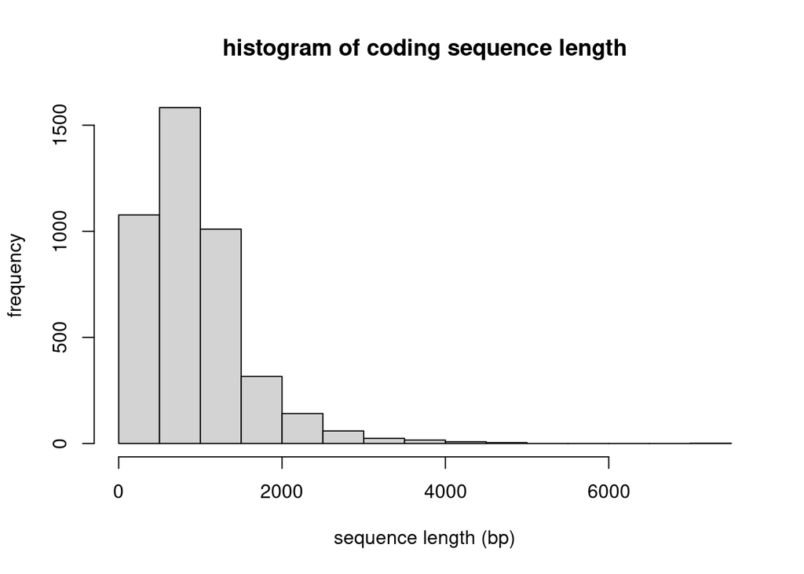

```r
hist(len,xlab="sequence length (bp)",ylab="frequency",main="histogram of coding sequence length")
```

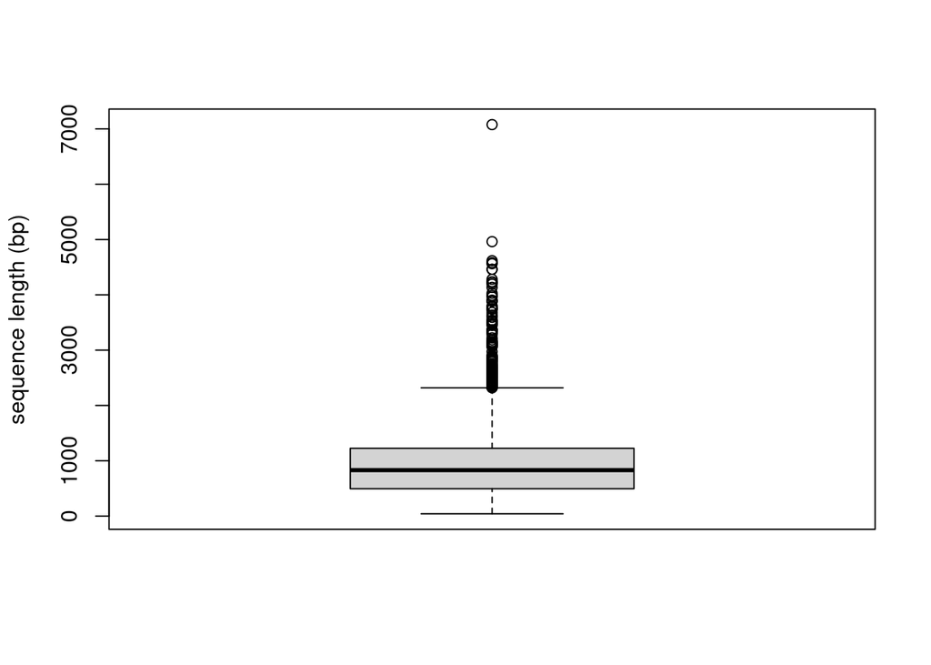

```r
boxplot(len,ylab="sequence length (bp)")
```

## Sequence composition: composition of DNA sequences First with one sequence, then with the whole set of coding sequences.

use ?GC ?count and ?summary to see the documentation for those seqinr commands.

cds is a list containing multiple sequences. To access a specific element within a list, such as the first sequence, we use double square brackets ([[ ]]). This syntax retrieves the actual sequence object from the list. For example, cds[[1]] extracts the first sequence from the cds list. We can then pass this to the GC function to compute its GC content.

```r
GC(cds[[1]])
```

```
## [1] 0.5151515
```

Let’s count the number of each nucleotide present in this gene. count(cds[[1]],1) # to count the number of each nucleotide present in gene 1

count(cds[[1]],2) # We can also calculate the occurrence of two-nucleotide combinations in our first gene.

E.g., to go to gene 2, put 2 in the first box. The last box represents (number)-nucleotide combinations. This is also how to find MOTIFS… the different combinations and the numbers of them.

```r
count(cds[[2]],3)
```

```
##
## aaa aac aag aat aca acc acg act aga agc agg agt ata atc atg att caa cac cag cat
##  58  37  38  43  15  36  33  29  19  28  30  25  22  41  55  43  39  24  37  30
## cca ccc ccg cct cga cgc cgg cgt cta ctc ctg ctt gaa gac gag gat gca gcc gcg gct
##  36  27  57  23  50  60  46  43  14  29  72  28  64  22  19  54  43  56  76  45
## gga ggc ggg ggt gta gtc gtg gtt taa tac tag tat tca tcc tcg tct tga tgc tgg tgt
##  37  64  26  43  17  29  46  50  15  30   8  33  36  24  33  46  54  68  68  31
## tta ttc ttg ttt
##  33  40  48  36
```

If you want to count the total length or compute the GC content of a specific number of genes from a list, you will need to unlist them first. For instance, length(unlist(cds[1:3])) extracts the first three sequences from the cds list, converts them into a single character vector using unlist, and then calculates the total length of this combined vector.

length(unlist(cds[1:3]))

And if you want to measure the GC content of these three genes you wrap it with GC function instead of length

GC(unlist(cds[1:3]))

Code below is for: length and GC content of the WHOLE GENOME

```r
length(unlist(cds))
```

```
## [1] 3978528
```

```r
GC(unlist(cds))
```

```
## [1] 0.5193114
```

If we want to analyze the nucleotide composition of a DNA sequence, we first need to unlist the cds, store it in the dna variable and then calculate the frequency of each nucleotide using dna_composition <- count(dna, 1), which stores these frequencies in dna_composition.

We then visualize this data with barplot(dna_composition, xlab=“nucleotides”, ylab=“frequency”, main=“E coli CDS composition”). This creates a bar plot where the x-axis represents the nucleotides (A, C, G, T), the y-axis shows their frequencies, and the plot title indicates that it displays the nucleotide composition of E. coli coding sequences.

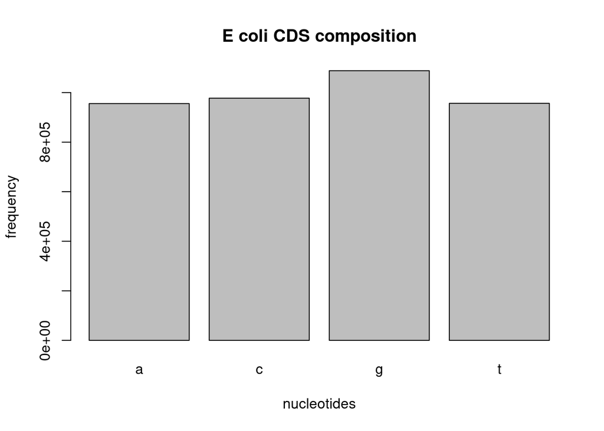

```r
dna <- unlist(cds)
dna_composition <- count(dna,1)
barplot(dna_composition,xlab="nucleotides",ylab="frequency", main="E coli CDS composition")
```

If we want to calculate the relative frequencies of each nucleotide in a DNA sequence, we first count the number of each nucleotide using dna_composition <- count(dna, 1). To find the relative frequencies, we divide each nucleotide count by the total number of nucleotides using dna_composition / sum(dna_composition). This step transforms the raw counts into proportions, showing the frequency of each nucleotide as a fraction of the total, which helps in understanding the distribution of nucleotides within the sequence.

```r
dna_composition/sum(dna_composition)
```

```
##
##         a         c         g         t
## 0.2402316 0.2457175 0.2735939 0.2404570
```

We can also plot of our nucleotide frequencies by using the following code

**note first line is added

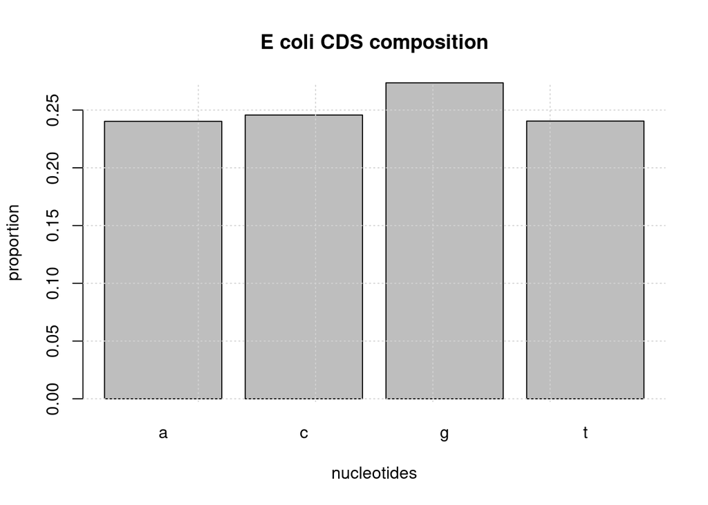

```r
dna_proportion <- dna_composition / sum(dna_composition)
barplot(dna_proportion,xlab="nucleotides",ylab="proportion", main="E coli CDS composition")
grid()
```

## Translation Now perform similar analysis for protein sequences. First, we need to translate the sequences. For example, the code below will translate your first CDS

```r
translate(cds[[1]])
```

```
##  [1] "M" "K" "R" "I" "S" "T" "T" "I" "T" "T" "T" "I" "T" "I" "T" "T" "G" "N" "G"
## [20] "A" "G" "*"
```

Although we have not learned loops in R, we will have to use a for loop if we want to translate all the cds sequences in our genome. The good news is that for loops work almost similar to what we learned in bash.

In the code below, prot <- list() initializes an empty list to store the translated sequences. The for loop, for (i in seq_along(cds)) { prot[[i]] <- translate(cds[[i]]) }, iterates over each sequence in cds using indices generated by seq_along(cds), applies the translate function to each sequence, and stores the resulting translated sequence in the corresponding position in the prot list.

```r
prot <- list()
for (i in seq_along(cds))
    {prot[[i]] <- translate(cds[[i]]) }
```

You might find it a bit more complex than the bash we used before. Luckily, R has another way of performing loops with apply functions. (use over previous!)

In the code, lapply applies the translate function to each element of the cds list, resulting in prot, a list of translated protein sequences.

```r
prot <- lapply(cds, translate)
```

We can use the prot list to get any useful information, such as the number of unique amino acids. aa <- unique(prot[[2]]) extracts these amino acids, aa <- aa[aa != “*”] removes any asterisks for unknown amino acids, and length(aa) counts the remaining unique amino acids.

```r
aa <- unique(prot[[2]])
aa <- aa[aa != "*"]
length(aa)
```

```
## [1] 20
```

Let’s determine the frequency of each amino acid in our first gene. This code counts the occurrences of each amino acid in the first sequence of the prot list, using aa as the set of possible amino acids.

```r
count(prot[[1]],wordsize=1,alphabet=aa)
```

```
##
## A C D E F G H I K L M N P Q R S T V W Y
## 1 0 0 0 0 3 0 4 1 0 1 1 0 0 1 1 8 0 0 0
```

And for the second gene

```r
count(prot[[2]],wordsize=1,alphabet=aa)
```

```
##
##  A  C  D  E  F  G  H  I  K  L  M  N  P  Q  R  S  T  V  W  Y
## 91 12 44 53 30 63 14 46 34 89 23 38 29 30 46 51 34 69  4 20
```

## Codon usage

A codon is a three base triplet that codes for a particular amino acid. As there are 64 possible codons and just 20 amino acids (and 3 termination codons), some amino acids are coded by multiple codons. For example, leucine is coded by six codons.

seqinr has a command called uco which calculates some codon usage information.

Let’s have a look at how it can calculate codon usage for a single protein sequence.

The function uco(cds[[2]]) returns the unique codons used in the second sequence of the cds list.

```r
uco(cds[[2]])
```

```
##
## aaa aac aag aat aca acc acg act aga agc agg agt ata atc atg att caa cac cag cat
##  22  16  12  22   2  19   8   5   0  12   2   3   1  15  23  30  11   6  19   8
## cca ccc ccg cct cga cgc cgg cgt cta ctc ctg ctt gaa gac gag gat gca gcc gcg gct
##   2   6  18   3   3  19   4  18   2  13  43   8  40  14  13  30  14  36  26  15
## gga ggc ggg ggt gta gtc gtg gtt taa tac tag tat tca tcc tcg tct tga tgc tgg tgt
##   9  22  10  22   5  18  27  19   0   8   0  12   6  10   9  11   1   9   4   3
## tta ttc ttg ttt
##  10  19  13  11
```

What if you wanted to calculate synonymous codons? A synonymous codon is a codon that codes for the same amino acids. The code below computes the Relative Synonymous Codon Usage (RSCU) values for the codons in the second sequence

```r
uco(cds[[2]],index="rscu")
```

```
##        aaa        aac        aag        aat        aca        acc        acg
## 1.29411765 0.84210526 0.70588235 1.15789474 0.23529412 2.23529412 0.94117647
##        act        aga        agc        agg        agt        ata        atc
## 0.58823529 0.00000000 1.41176471 0.26086957 0.35294118 0.06521739 0.97826087
##        atg        att        caa        cac        cag        cat        cca
## 1.00000000 1.95652174 0.73333333 0.85714286 1.26666667 1.14285714 0.27586207
##        ccc        ccg        cct        cga        cgc        cgg        cgt
## 0.82758621 2.48275862 0.41379310 0.39130435 2.47826087 0.52173913 2.34782609
##        cta        ctc        ctg        ctt        gaa        gac        gag
## 0.13483146 0.87640449 2.89887640 0.53932584 1.50943396 0.63636364 0.49056604
##        gat        gca        gcc        gcg        gct        gga        ggc
## 1.36363636 0.61538462 1.58241758 1.14285714 0.65934066 0.57142857 1.39682540
##        ggg        ggt        gta        gtc        gtg        gtt        taa
## 0.63492063 1.39682540 0.28985507 1.04347826 1.56521739 1.10144928 0.00000000
##        tac        tag        tat        tca        tcc        tcg        tct
## 0.80000000 0.00000000 1.20000000 0.70588235 1.17647059 1.05882353 1.29411765
##        tga        tgc        tgg        tgt        tta        ttc        ttg
## 3.00000000 1.50000000 1.00000000 0.50000000 0.67415730 1.26666667 0.87640449
##        ttt
## 0.73333333
```

If want to get these values in a data frame we can use the option as.data.frame=True

```r
uco(cds[[2]],index="rscu",as.data.frame=TRUE)
```

```
##      AA codon eff        freq       RSCU
## aaa Lys   aaa  22 0.026796590 1.29411765
## aac Asn   aac  16 0.019488429 0.84210526
## aag Lys   aag  12 0.014616322 0.70588235
## aat Asn   aat  22 0.026796590 1.15789474
## aca Thr   aca   2 0.002436054 0.23529412
## acc Thr   acc  19 0.023142509 2.23529412
## acg Thr   acg   8 0.009744214 0.94117647
## act Thr   act   5 0.006090134 0.58823529
## aga Arg   aga   0 0.000000000 0.00000000
## agc Ser   agc  12 0.014616322 1.41176471
## agg Arg   agg   2 0.002436054 0.26086957
## agt Ser   agt   3 0.003654080 0.35294118
## ata Ile   ata   1 0.001218027 0.06521739
## atc Ile   atc  15 0.018270402 0.97826087
## atg Met   atg  23 0.028014616 1.00000000
## att Ile   att  30 0.036540804 1.95652174
## caa Gln   caa  11 0.013398295 0.73333333
## cac His   cac   6 0.007308161 0.85714286
## cag Gln   cag  19 0.023142509 1.26666667
## cat His   cat   8 0.009744214 1.14285714
## cca Pro   cca   2 0.002436054 0.27586207
## ccc Pro   ccc   6 0.007308161 0.82758621
## ccg Pro   ccg  18 0.021924482 2.48275862
## cct Pro   cct   3 0.003654080 0.41379310
## cga Arg   cga   3 0.003654080 0.39130435
## cgc Arg   cgc  19 0.023142509 2.47826087
## cgg Arg   cgg   4 0.004872107 0.52173913
## cgt Arg   cgt  18 0.021924482 2.34782609
## cta Leu   cta   2 0.002436054 0.13483146
## ctc Leu   ctc  13 0.015834348 0.87640449
## ctg Leu   ctg  43 0.052375152 2.89887640
## ctt Leu   ctt   8 0.009744214 0.53932584
## gaa Glu   gaa  40 0.048721072 1.50943396
## gac Asp   gac  14 0.017052375 0.63636364
## gag Glu   gag  13 0.015834348 0.49056604
## gat Asp   gat  30 0.036540804 1.36363636
## gca Ala   gca  14 0.017052375 0.61538462
## gcc Ala   gcc  36 0.043848965 1.58241758
## gcg Ala   gcg  26 0.031668697 1.14285714
```

[output cut: 10 more lines]

```
## tac Tyr   tac   8 0.009744214 0.80000000
## tag Stp   tag   0 0.000000000 0.00000000
## tat Tyr   tat  12 0.014616322 1.20000000
## tca Ser   tca   6 0.007308161 0.70588235
## tcc Ser   tcc  10 0.012180268 1.17647059
## tcg Ser   tcg   9 0.010962241 1.05882353
## tct Ser   tct  11 0.013398295 1.29411765
## tga Stp   tga   1 0.001218027 3.00000000
## tgc Cys   tgc   9 0.010962241 1.50000000
## tgg Trp   tgg   4 0.004872107 1.00000000
## tgt Cys   tgt   3 0.003654080 0.50000000
## tta Leu   tta  10 0.012180268 0.67415730
## ttc Phe   ttc  19 0.023142509 1.26666667
## ttg Leu   ttg  13 0.015834348 0.87640449
## ttt Phe   ttt  11 0.013398295 0.73333333
```

## Kmer profiling

K-mer is simply a short sequence string of length k. We can use k-mer analysis to identify particular sequences that are over- or under-represented in an organism.

```r
prots <- unlist(prot)
mycounts <- count(prots,wordsize=3,alphabet=aa)
str(mycounts)
```

```
##  'table' int [1:8000(1d)] 1338 182 568 749 481 1075 222 863 580 1594 ...
##  - attr(*, "dimnames")=List of 1
##   ..$ : chr [1:8000] "AAA" "AAC" "AAD" "AAE" ...
```

```r
head(mycounts)
```

```
##
##  AAA  AAC  AAD  AAE  AAF  AAG
## 1338  182  568  749  481 1075
```

```r
myfreq <- count(prots,wordsize=3,alphabet=aa,freq=TRUE)
```